# PSTAT131_HW3

### Question 4

Using the **training** data, create a recipe predicting the outcome variable `survived`. Include the following predictors: ticket class, sex, age, number of siblings or spouses aboard, number of parents or children aboard, and passenger fare.

Recall that there were missing values for `age`. To deal with this, add an imputation step using `step_impute_linear()`. Next, use `step_dummy()` to **dummy** encode categorical predictors. Finally, include interactions between:

- Sex and passenger fare, and
- Age and passenger fare.

You’ll need to investigate the `tidymodels` documentation to find the appropriate step functions to use.

```r
# Using the **training** data, create a recipe predicting the outcome variable `survived`.
titanic_recipe <-recipe(survived ~ pclass + sex + age + sib_sp +parch + fare,
                              data = titanic_train) %>%
step_impute_linear(age) %>%
step_dummy(all_nominal_predictors())  %>%
step_interact(terms = ~ starts_with('sex'):fare)%>%
step_interact(terms = ~ age:fare)

titanic_recipe # check the titanic_train_recipe
```

```
## Recipe
##
## Inputs:
##
##       role #variables
##    outcome          1
##  predictor          6
##
## Operations:
##
## Linear regression imputation for age
## Dummy variables from all_nominal_predictors()
## Interactions with starts_with("sex"):fare
## Interactions with age:fare
```

### Question 5

Specify a **logistic regression** model for classification using the `"glm"` engine. Then create a workflow. Add your model and the appropriate recipe. Finally, use `fit()` to apply your workflow to the **training** data.

*Hint: Make sure to store the results of `fit()`. You’ll need them later on.*

```r
# Specify a **logistic regression** model for classification using the `"glm"` engine.
log_reg <- logistic_reg() %>%
  set_engine("glm") %>%
  set_mode("classification")

# Then create a workflow. Add your model and the appropriate recipe.
log_wkflow <- workflow() %>%
  add_model(log_reg) %>%
  add_recipe(titanic_recipe)

#  Finally, use `fit()` to apply my workflow to the **training** data.
log_fit <- fit(log_wkflow, titanic_train)
```

### Question 6

**Repeat Question 5**, but this time specify a linear discriminant analysis model for classification using the `"MASS"` engine.

```r
lda_mod <- discrim_linear() %>%
  set_mode("classification") %>%
  set_engine("MASS")

lda_wkflow <- workflow() %>%
  add_model(lda_mod) %>%
  add_recipe(titanic_recipe)

lda_fit <-fit(lda_wkflow, titanic_train)
```

### Question 7

**Repeat Question 5**, but this time specify a quadratic discriminant analysis model for classification using the `"MASS"` engine.

```r
qda_mod <- discrim_quad() %>%
  set_mode("classification") %>%
  set_engine("MASS")

qda_wkflow <- workflow() %>%
  add_model(qda_mod) %>%
  add_recipe(titanic_recipe)

qda_fit <- fit(qda_wkflow, titanic_train)
```

### Question 8

**Repeat Question 5**, but this time specify a naive Bayes model for classification using the `"klaR"` engine. Set the `usekernel` argument to `FALSE`.

```r
nb_mod <- naive_Bayes() %>%
  set_mode("classification") %>%
  set_engine("klaR") %>%
  set_args(usekernel = FALSE)

nb_wkflow <- workflow() %>%
  add_model(nb_mod) %>%
  add_recipe(titanic_recipe)

nb_fit <- fit(nb_wkflow, titanic_train)
```

### Question 9

Now you’ve fit four different models to your training data.

Use `predict()` and `bind_cols()` to generate predictions using each of these 4 models and your **training** data. Then use the *accuracy* metric to assess the performance of each of the four models.

Which model achieved the highest accuracy on the training data?

```r
# Use `predict()` and `bind_cols()` to generate predictions using
# each of these 4 models and your **training** data.
# according to the professor and TA, we use let type = 'class' here.
log_predict <- predict(log_fit, new_data = titanic_train, type = "class")

lda_predict<-predict(lda_fit, new_data =  titanic_train, type = "class")

qda_predict<-predict(qda_fit, new_data = titanic_train, type = "class")

nb_predict<-predict(nb_fit, new_data = titanic_train, type = "class")

titanic_train_predictions <- bind_cols(log_predict,lda_predict,qda_predict,nb_predict)
titanic_train_predictions %>% head()
```

```
## # A tibble: 6 × 4
##   .pred_class...1 .pred_class...2 .pred_class...3 .pred_class...4
##   <fct>           <fct>           <fct>           <fct>
## 1 No              No              No              No
## 2 No              No              No              No
## 3 No              No              No              No
## 4 No              No              No              No
## 5 No              Yes             No              No
## 6 No              No              No              No
```

```r
# Then use the *accuracy* metric to assess the performance of each of the four models.
log_reg_acc <- augment(log_fit, new_data = titanic_train) %>%
  accuracy(truth = survived, estimate = .pred_class)

lda_acc <- augment(lda_fit, new_data = titanic_train) %>%
  accuracy(truth = survived, estimate = .pred_class)

qda_acc <- augment(qda_fit, new_data = titanic_train) %>%
  accuracy(truth = survived, estimate = .pred_class)

nb_acc <- augment(nb_fit, new_data = titanic_train) %>%
  accuracy(truth = survived, estimate = .pred_class)
accuracies <- c(log_reg_acc$.estimate, lda_acc$.estimate,
                nb_acc$.estimate, qda_acc$.estimate)
models <- c("Logistic Regression", "LDA", "Naive Bayes", "QDA")
results <- tibble(accuracies = accuracies, models = models)
results %>%
  arrange(-accuracies)
```

```
## # A tibble: 4 × 2
##   accuracies models
##        <dbl> <chr>
## 1      0.819 Logistic Regression
## 2      0.803 LDA
## 3      0.789 QDA
## 4      0.784 Naive Bayes
```

- Which model achieved the highest accuracy on the training data?

Based on what we got, we know that logistic regression model achieved the highest accuracy on the training data.

### Question 10

Fit the model with the highest training accuracy to the **testing** data. Report the accuracy of the model on the **testing** data.

Again using the **testing** data, create a confusion matrix and visualize it. Plot an ROC curve and calculate the area under it (AUC).

How did the model perform? Compare its training and testing accuracies. If the values differ, why do you think this is so?

```r
# Fit the model with the highest training accuracy to the **testing** data.
predict(log_fit, new_data = titanic_test, type = 'class')
```

```
## # A tibble: 179 × 1
##    .pred_class
##    <fct>
##  1 Yes
##  2 No
##  3 No
##  4 Yes
##  5 No
##  6 Yes
##  7 No
##  8 No
##  9 Yes
## 10 Yes
## # … with 169 more rows
```

```r
# Report the accuracy of the model on the **testing** data.
new_acc <- augment(log_fit, new_data = titanic_test) %>%
  accuracy(truth = survived, estimate = .pred_class)
new_acc
```

```
## # A tibble: 1 × 3
##   .metric  .estimator .estimate
##   <chr>    <chr>          <dbl>
## 1 accuracy binary         0.782
```

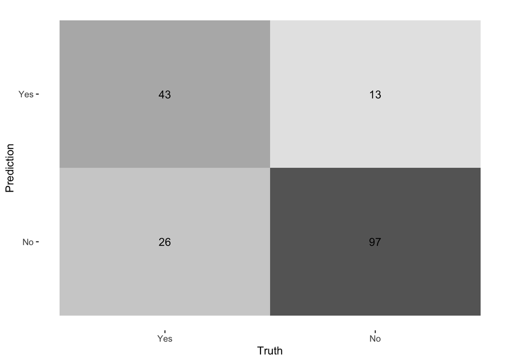

```r
# Again using the **testing** data, create a confusion matrix and visualize it.
augment(log_fit, new_data = titanic_test) %>%
  conf_mat(truth = survived, estimate = .pred_class)%>%
  autoplot(type = "heatmap")
```

```r
# In order to help us to understand ROC better
# we  we add two other metrics, sensitivity and specificity, out of curiosit
multi_metric <- metric_set(accuracy, sensitivity, specificity)

augment(log_fit, new_data = titanic_test) %>%
  multi_metric(truth = survived, estimate = .pred_class)
```

```
## # A tibble: 3 × 3
##   .metric     .estimator .estimate
##   <chr>       <chr>          <dbl>
## 1 accuracy    binary         0.782
## 2 sensitivity binary         0.623
## 3 specificity binary         0.882
```

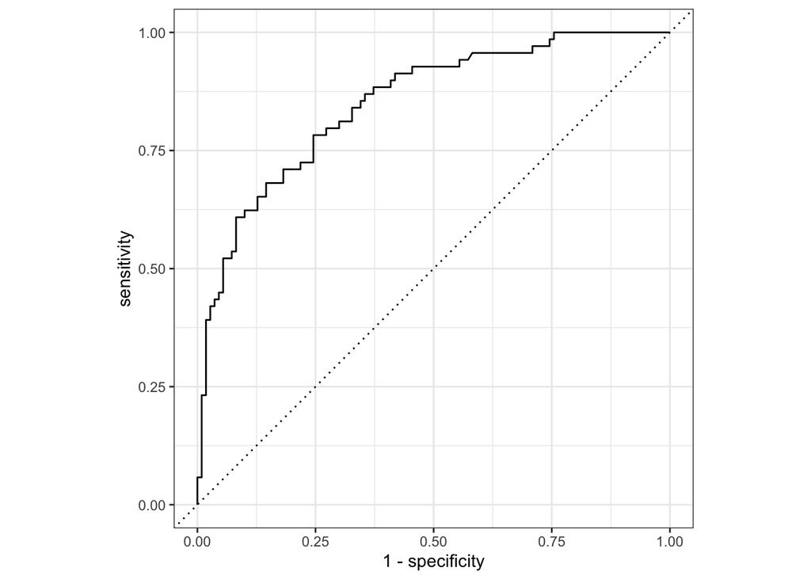

```r
# Plot an ROC curve
augment(log_fit, new_data = titanic_test) %>%
  roc_curve(survived, .pred_Yes) %>%
  autoplot()
```

```r
# Calculate the area under it (AUC).
augment(log_fit, new_data = titanic_test) %>%
   roc_auc(survived,.pred_Yes)
```

```
## # A tibble: 1 × 3
##   .metric .estimator .estimate
##   <chr>   <chr>          <dbl>
## 1 roc_auc binary         0.850
```

- How did the model perform?

Well, the AUC we got is about 0.8502 (close to 1). By what we learned about AUC, we can conclude that our model perform good. According to the professor, an AUC above 0.85 means high classification accuracy.

- Compare its training and testing accuracies.

The training accuracy is 0.818820. The testing accuracy is 0.7821229. We can that The testing accuracy is smaller than the training accuracy. They are different.

- If the values differ, why do you think this is so?

According to the lecture, we know that the testing accuracy is smaller than the training accuracy because we use 80% of data in the training dataset and 20% in the testing dataset. When we use more data, our model will be more accurate. I think it will be a very important reason why our testing accuracy is smaller than our training accuracy.